# R ile Temel Trend Analizleri

İklim Değişikliği İzinde Türkiye

Doç. Dr. Hasan BULUT

# 1 **Arttırılmış Dickey-Fuller (ADF) Testi**

Birim-Kök testleri veri setinin durağan olup-olmadığını inceler. Dolayısıyla veri durağansa trend olmadığı, durağan değilse trend olduğu şeklinde bir sonuca varabiliriz. Burada test edilen hipotezler:

$$H_0: Veri \ durağan \ değildir \ (Birim \ kök \ vardır)$$

$$H_1: Veri \ durağandır\ (Birim \ kök \ yoktur)$$

En popüler birim kök testlerinden birisi Arttırılmış (Augmented) Dickey-Fuller (ADF) testidir (Dickey and Fuller 1979). R programında ADF testi **tseries** paketinde bulunan `adf.test()` fonksiyonu yardımıyla yapılabilir (Trapletti and Hornik 2024).

Aşağıda zamanla değişen bir veri setine sahip olduğumuzu varsayalım.

$$X: 2,8,3,1,7,5,12,8,10,14,9,19,21$$

Bu veri R programına aşağıdaki gibi girilebilir.

```r
x<-c(2,8,3,1,7,5,12,8,10,14,9,19,21)
x
```

```
##  [1]  2  8  3  1  7  5 12  8 10 14  9 19 21
```

Bu veriye ADF testi yapmak için öncelikle **tseries** paketinin indirilip, kütüphaneden çağrılması gerekmektedir. Bu işlem aşağıdaki gibi yapılabilir. Paketi ilk kez indirirken internet bağlantısı gerekir.

```r
# install.packages("tseries")
library(tseries)
```

Artık **tseries** paketindeki `adf.test()` fonksiyonuyla `x` nesnesindeki veriye ADF testi aşağıdaki gibi yapılabilir.

```r
adf.test(x)
```

```
##
##  Augmented Dickey-Fuller Test
##
## data:  x
## Dickey-Fuller = -1.8752, Lag order = 2, p-value = 0.6199
## alternative hypothesis: stationary
```

Burada $p-değeri=0.6199>0.05$ olduğundan yokluk hipotezi reddedilememiştir. Buna göre veri setinde durağanlık olmadığı söylenebilir. Durağanlığın olmaması trendin varlığı için bir işarettir.

# 2 **Mann-Kendall (MK) Trend Analizi**

Mann-Kendall testi doğrudan bir veri setinde zamana bağlı bir trendin varlığını incelemek için kullanılabilen nonparametrik bir hipotez testidir. Test edilen hipotezler kabaca aşağıdaki gibi verilebilir:

$$H_0: Veri \ setinde \ trend \ yoktur.$$

$$H_1: Veri \ setinde \ trend \ vardır.$$

R programında MK testini yapmak için *trend* paketinde bulunan **`mk.test()`** fonksiyonu kullanılabilir (Pohlert 2023).

Daha önce tanımlanan `x` verisi için MK testi aşağıdaki gibi gerçekleştirilebilir.

```r
library(trend)
mk.test(x)
```

```
##
##  Mann-Kendall trend test
##
## data:  x
## z = 3.1784, n = 13, p-value = 0.001481
## alternative hypothesis: true S is not equal to 0
## sample estimates:
##           S        varS         tau
##  53.0000000 267.6666667   0.6838852
```

Burada $p-değeri=0.001481<0.01$ olduğundan %99 güvenle yokluk hipotezi reddedilir ve veri setinde istatistiksel olarak anlamlı bir trend olduğu söylenebilir. Burada $\tau=0.684$ değeri zamanla x verilerindeki değişim arasındaki Kendall $\tau$ korelasyon değeri olup, bu değer pozitif olduğundan artış yönünde bir trend olduğu sonucuna varılmıştır. Bu artış trendi aşağıdaki gibi görselleştirilebilir.

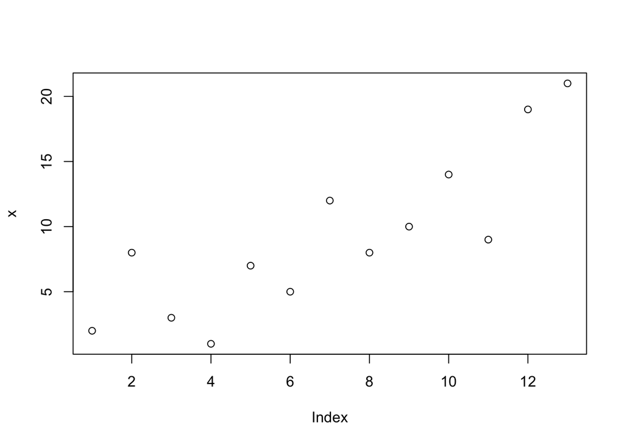

```r
plot(x)
```

# 3 **Yenilikçi Şen Yöntemi**

Bu yöntem 2011 yılında Zekai Şen tarafından literatüre kazandırılmış ve Yenilikçi (innovative) Şen yöntemi olarak anılmaktadır (Şen 2012). R programında bu yöntem *trendchange* paketinde bulunan **`innovtrend()`** fonksiyonu yardımıyla aşağıdaki gibi kullanılabilir (Patakamuri and Das 2022).

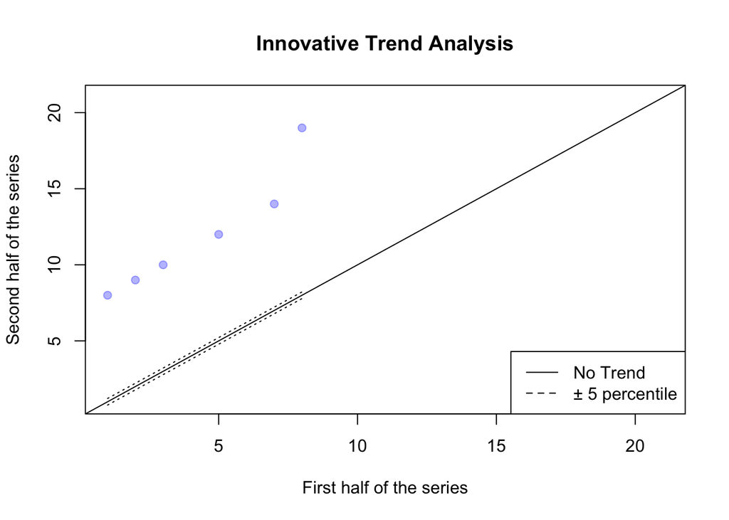

```
##                        Trend Slope                    Trend Indicator
##                          1.1794872                         17.6923077
##           Slope Standard deviation                        Correlation
##                          0.0819054                          0.9508378
## Lower Cofidence Limit at 90percent Upper Cofidence Limit at 90percent
##                         -0.1347344                          0.1347344
## Lower Cofidence Limit at 95percent Upper Cofidence Limit at 95percent
##                         -0.1605346                          0.1605346
## Lower Cofidence Limit at 99percent Upper Cofidence Limit at 99percent
##                         -0.2109883                          0.2109883
```

```r
library(trendchange)
innovtrend(x)
```

Görüldüğü gibi noktalar doğrunun üst kısmında yer almaktadır ve bu durum veri setinde artan bir trend olduğunu göstermektedir.

# 4 **Sen’in Slope Değeri**

Burada trendi belirledikten sonra bu trendin büyüklüğü ve yönünün incelemenin bir yoluda Sen’in eğim değerini hesaplamaktır (Sen 1968). R programında Sen’in eğim değeri *trend* paketindeki `sens.slope()` fonksiyonu yardımıyla aşağıdaki gibi hesaplanabilir (Pohlert 2023).

```r
sens.slope(x)
```

```
##
##  Sen's slope
##
## data:  x
## z = 3.1784, n = 13, p-value = 0.001481
## alternative hypothesis: true z is not equal to 0
## 95 percent confidence interval:
##  0.7 2.0
## sample estimates:
## Sen's slope
##        1.45
```

Buna göre eğim değeri 1.45 olup, pozitif olduğu için trendin artış yönünde olduğu görülmüştür. Buna göre birim zamanda x değerinin 1.45 birim arttığı söylenebilir. Bu eğim katsayısının %99 güvenle istatistiksel olarak anlamlı olduğu da p değerine bakılarak görülmektedir (p değeri=0.001481<0.01).

# **Kaynaklar**

Dickey, David A., and Wayne A. Fuller. 1979. “Distribution of the Estimators for Autoregressive Time Series with a Unit Root.” *Journal of the American Statistical Association* 74 (366): 427. https://doi.org/10.2307/2286348.

Patakamuri, Sandeep Kumar, and Bappa Das. 2022. “Trendchange: Innovative Trend Analysis and Time-Series Change Point Analysis.” https://CRAN.R-project.org/package=trendchange.

Pohlert, Thorsten. 2023. “Trend: Non-Parametric Trend Tests and Change-Point Detection.” https://CRAN.R-project.org/package=trend.

Sen, Pranab Kumar. 1968. “Estimates of the Regression Coefficient Based on Kendall’s Tau.” *Journal of the American Statistical Association* 63 (324): 1379–89. https://doi.org/10.1080/01621459.1968.10480934.

Şen, Zekâi. 2012. “Innovative Trend Analysis Methodology.” *Journal of Hydrologic Engineering* 17 (9): 1042–46. https://doi.org/10.1061/(asce)he.1943-5584.0000556.

Trapletti, Adrian, and Kurt Hornik. 2024. “Tseries: Time Series Analysis and Computational Finance.” https://CRAN.R-project.org/package=tseries.